# Tugas Individu 67

Zulfa Hafizhoh

2023-10-10

## Packages

```r
library(ggplot2)
library(tsibble)
library(tseries)
library(MASS)
library(forecast)
library(TSA)
library(TTR)
library(aTSA)
library(graphics)
```

## Input Data

```r
data<-rio::import("https://raw.githubusercontent.com/zulfah6/MPDW/main/Pertemuan%2067/Data%20Inflasi.csv")

#Mengambil hanya kolom Close sebagai data baru
datainflasi <- data$Inflasi
datainflasi
```

```
##   [1] 3.72 3.81 3.43 3.91 4.16 5.05 6.22 6.44 5.80 5.67 6.33 6.96 7.02 6.84 6.65
##  [16] 6.16 5.98 5.54 4.61 4.79 4.61 4.42 4.15 3.79 3.65 3.56 3.97 4.50 4.45 4.53
##  [31] 4.56 4.58 4.31 4.61 4.32 4.30 4.57 5.31 5.90 5.57 5.47 5.90 8.61 8.79 8.40
##  [46] 8.32 8.37 8.38 8.22 7.75 7.32 7.25 7.32 6.70 4.53 3.99 4.53 4.83 6.23 8.36
##  [61] 6.96 6.29 6.38 6.79 7.15 7.26 7.26 7.18 6.83 6.25 4.89 3.35 4.14 4.42 4.45
##  [76] 3.60 3.33 3.45 3.21 2.79 3.07 3.31 3.58 3.02 3.49 3.83 3.61 4.17 4.33 4.37
##  [91] 3.88 3.82 3.72 3.58 3.30 3.61 3.25 3.18 3.40 3.41 3.23 3.12 3.18 3.20 2.88
## [106] 3.16 3.23 3.13 2.82 2.57 2.48 2.83 3.32 3.28 3.32 3.49 3.39 3.13 3.00 2.72
## [121] 2.68 2.98 2.96 2.67 2.19 1.96 1.54 1.32 1.42 1.44 1.59 1.68 1.55 1.38 1.37
## [136] 1.42 1.68 1.33 1.52 1.59 1.60 1.66 1.75 1.87 2.18 2.06 2.64 3.47 3.55 4.35
## [151] 4.94 4.69 5.95 5.71 5.42 5.51 5.28 5.47 4.97 4.33
```

```r
#Mengganti tipe data menjadi time series
datainflasi.ts<-ts(datainflasi)
```

### Eksplorasi Data

#### Plot Data Penuh

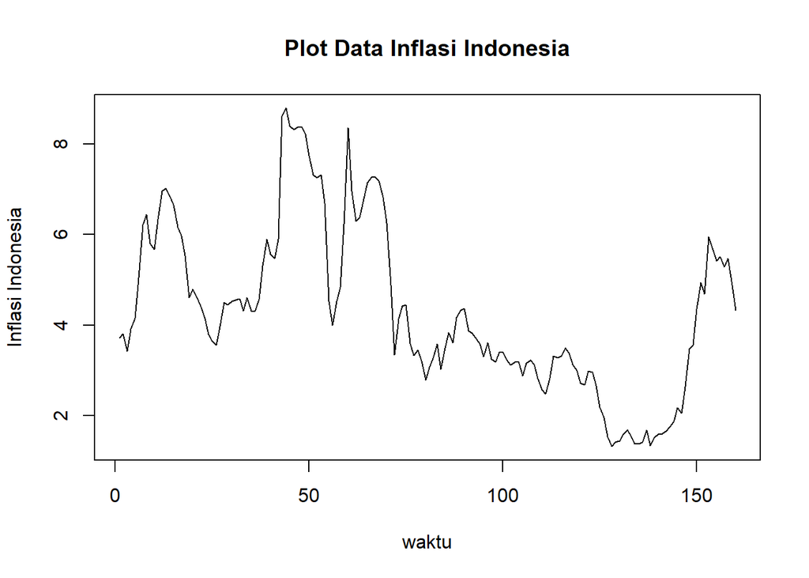

```r
plot.ts(datainflasi.ts, lty=1, xlab="waktu", ylab="Inflasi Indonesia", main="Plot Data Inflasi Indonesia")
```

Berdasarkan plot data deret waktu, terlihat bahwa data cenderung memiliki pola trend dan musiman. Berdasarkan pola data, pembagian data latih dan data uji ditetapkan dengan proporsi 7:3.

#### Plot Data Latih

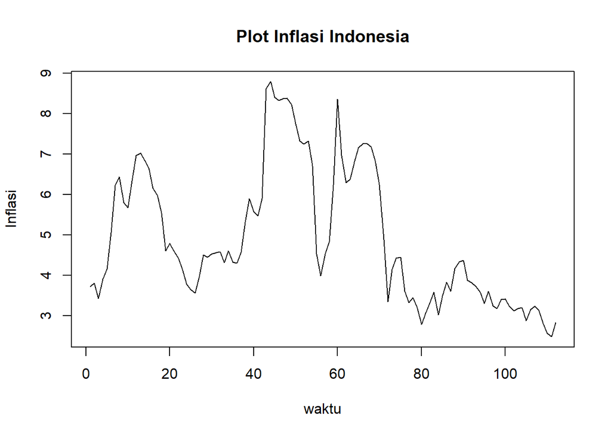

```r
Inflasitrain<-datainflasi[1:112]
train.ts<-ts(Inflasitrain)
plot.ts(train.ts, lty=1, xlab="waktu", ylab="Inflasi", main="Plot Inflasi Indonesia")
```

#### Plot Data Uji

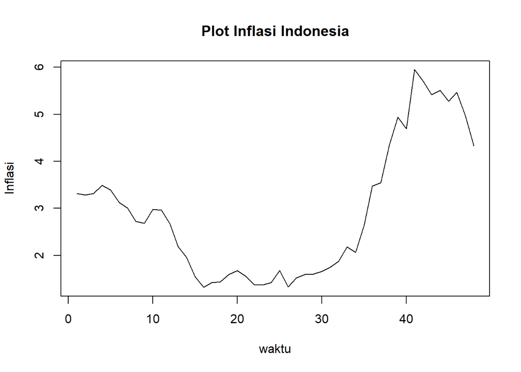

```r
Inflasitest<-datainflasi[113:160]
test.ts<-ts(Inflasitest)
plot.ts(test.ts, lty=1, xlab="waktu", ylab="Inflasi", main="Plot Inflasi Indonesia")
```

### Uji Stasioneritas Data

#### Plot ACF

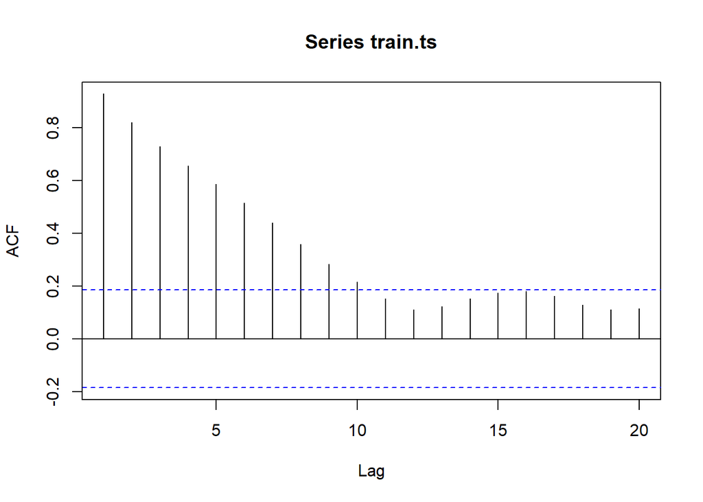

```r
acf(train.ts)
```

Berdasarkan plot ACF, terlihat bahwa plot ACF pada data tersebut cenderung *tails off* . Hal ini juga menjadi indikasi bahwa data tidak stasioner dalam rataan.

#### Uji ADF

```r
tseries::adf.test(train.ts)
```

```
##
##  Augmented Dickey-Fuller Test
##
## data:  train.ts
## Dickey-Fuller = -2.6761, Lag order = 4, p-value = 0.296
## alternative hypothesis: stationary
```

$H_0$ : Data tidak stasioner dalam rataan

$H_1$ : Data stasioner dalam rataan

Berdasarkan uji ADF tersebut, didapat *p-value* sebesar 0.296 yang lebih besar dari taraf nyata 5% sehingga tak tolak $H_0$ dan menandakan bahwa data tidak stasioner dalam rataan. Hal ini sesuai dengan hasil eksplorasi menggunakan plot time series dan plot ACF, sehingga dapat dilanjutkan ke ketidakstasioneran model ke depannya.

### Plot Box-Cox

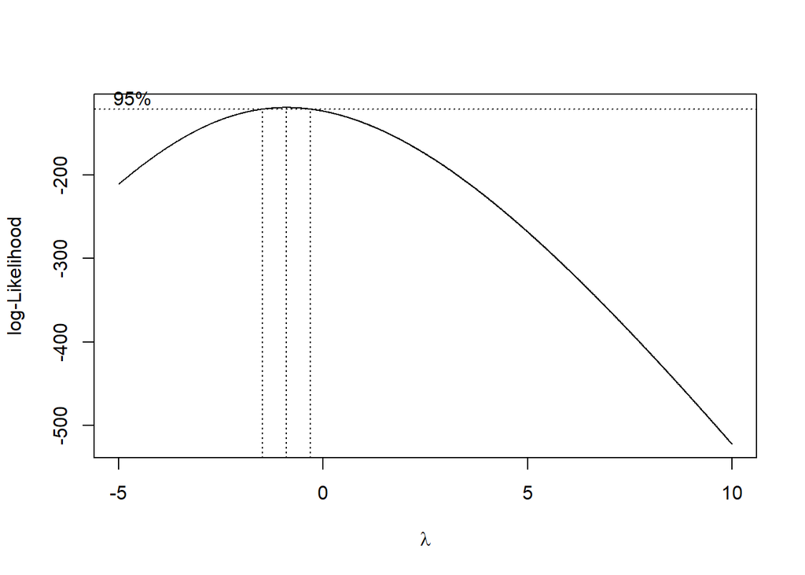

```r
index <- seq(1:112)
bc = boxcox(train.ts~index, lambda = seq(-5,10,by=0.01))
```

```r
#Nilai Rounded Lambda
lambda <- bc$x[which.max(bc$y)]
lambda
```

```
## [1] -0.9
```

```r
#SK
bc$x[bc$y > max(bc$y) - 1/2 * qchisq(.95,1)]
```

```
##   [1] -1.48 -1.47 -1.46 -1.45 -1.44 -1.43 -1.42 -1.41 -1.40 -1.39 -1.38 -1.37
##  [13] -1.36 -1.35 -1.34 -1.33 -1.32 -1.31 -1.30 -1.29 -1.28 -1.27 -1.26 -1.25
##  [25] -1.24 -1.23 -1.22 -1.21 -1.20 -1.19 -1.18 -1.17 -1.16 -1.15 -1.14 -1.13
##  [37] -1.12 -1.11 -1.10 -1.09 -1.08 -1.07 -1.06 -1.05 -1.04 -1.03 -1.02 -1.01
##  [49] -1.00 -0.99 -0.98 -0.97 -0.96 -0.95 -0.94 -0.93 -0.92 -0.91 -0.90 -0.89
##  [61] -0.88 -0.87 -0.86 -0.85 -0.84 -0.83 -0.82 -0.81 -0.80 -0.79 -0.78 -0.77
##  [73] -0.76 -0.75 -0.74 -0.73 -0.72 -0.71 -0.70 -0.69 -0.68 -0.67 -0.66 -0.65
##  [85] -0.64 -0.63 -0.62 -0.61 -0.60 -0.59 -0.58 -0.57 -0.56 -0.55 -0.54 -0.53
##  [97] -0.52 -0.51 -0.50 -0.49 -0.48 -0.47 -0.46 -0.45 -0.44 -0.43 -0.42 -0.41
## [109] -0.40 -0.39 -0.38 -0.37 -0.36 -0.35 -0.34 -0.33 -0.32 -0.31
```

Plot Boxcox menunjukkan nilai rounded value (λ) optimum sebesar -0.9 dan pada selang kepercayaan 95% nilai memiliki batas bawah -1.48 dan batas atas -0.31. Selang tersebut tidak memuat nilai satu sehingga dapat dikatakan bahwa data yang digunakan tidak stasioner dalam ragam.

### Penangan Ketidakstasioneran Data

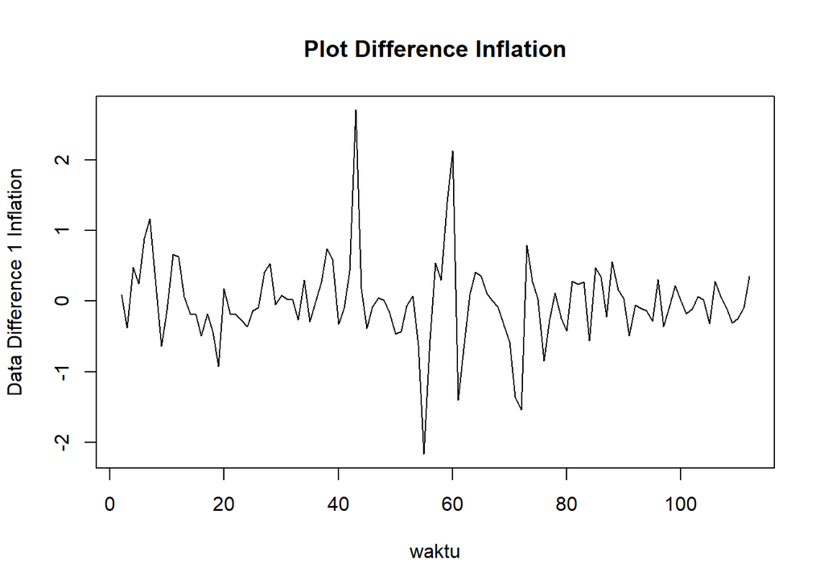

```r
train.diff<-diff(train.ts,differences = 1)
plot.ts(train.diff, lty=1, xlab="waktu", ylab="Data Difference 1 Inflation", main="Plot Difference Inflation")
```

Berdasarkan plot data deret waktu, terlihat bahwa data sudah stasioner dalam rataan ditandai dengan data bergerak pada nilai tengah tertentu (tidak terdapat trend ataupun musiman pada data)

### Plot ACF

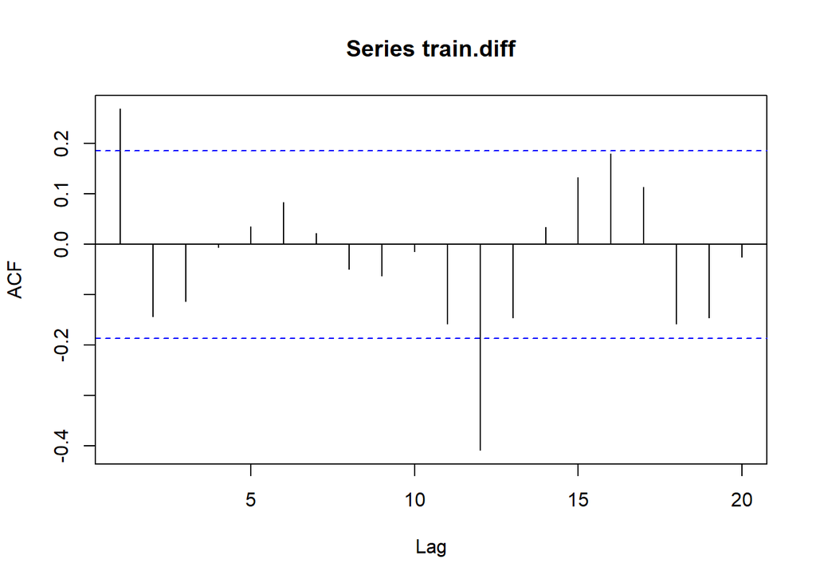

```r
acf(train.diff)
```

Berdasarkan plot tersebut, terlihat bahwa plot ACF cuts off pada lag ke 1. Hal ini menandakan data sudah stasioner dalam rataan dan ketidakstasioneran data telah berhasil tertangani.

### Uji ADF

```r
tseries::adf.test(train.diff)
```

```
##
##  Augmented Dickey-Fuller Test
##
## data:  train.diff
## Dickey-Fuller = -4.6668, Lag order = 4, p-value = 0.01
## alternative hypothesis: stationary
```

H0: Data tidak stasioner dalam rataan

H1: Data stasioner dalam rataan

Berdasarkan uji ADF tersebut, didapat p-value sebesar 0.01 yang lebih kecil dari taraf nyata 5% sehingga tolak H0 atau data stasioner dalam rataan. Hal ini sesuai dengan hasil eksplorasi menggunakan plot time series dan plot ACF, sehingga dalam hal ini ketidakstasioneran data dalam rataan sudah berhasil ditangani dan dapat dilanjutkan ke pemodelan

### Identifikasi Model

#### Plot ACF

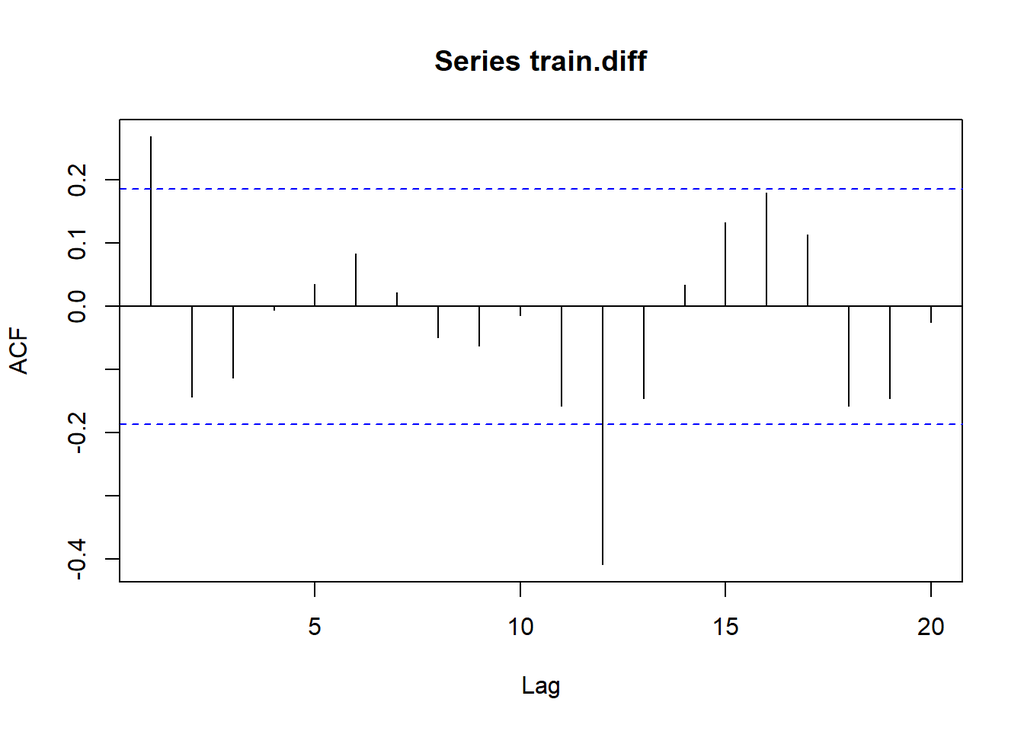

```r
acf(train.diff)
```

Berdasarkan plot tersebut, terlihat bahwa plot ACF cenderung *cuts off* pada lag ke 1, sehingga jika plot PACF dianggap *tails of*, maka model tentatifnya adalah ARIMA(0,1,1).

#### Plot PACF

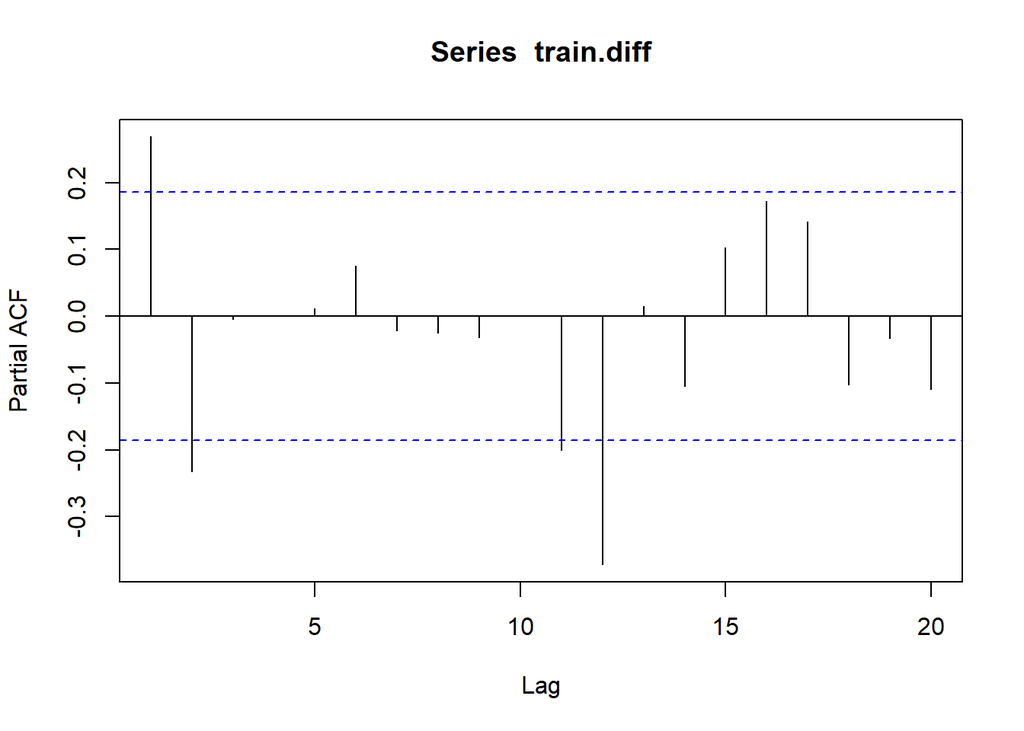

```r
pacf(train.diff)
```

Jika baik plot ACF maupun plot PACF keduanya dianggap tails of, maka model yang terbentuk adalah ARIMA(1,1,1)

#### Plot EACF

```r
eacf(train.diff)
```

```
## AR/MA
##   0 1 2 3 4 5 6 7 8 9 10 11 12 13
## 0 x o o o o o o o o o o  x  o  o
## 1 x x o o o o o o o o o  x  x  o
## 2 o o o o o o o o o o o  x  o  o
## 3 x o o o o o o o o o o  x  o  o
## 4 o o o x o o o o o o o  x  o  o
## 5 o o o o o o o o o o o  x  o  o
## 6 x x x o o o o o o o o  x  o  o
## 7 x o x o x o o o o o o  x  o  o
```

### Pendugaan Parameter Model Tentatif

#### ARIMA(0,1,1)

```r
model1.da=Arima(train.diff, order=c(0,1,1),method="ML")
summary(model1.da) #AIC=208.15
```

```
## Series: train.diff
## ARIMA(0,1,1)
##
## Coefficients:
##           ma1
##       -1.0000
## s.e.   0.0484
##
## sigma^2 = 0.3618:  log likelihood = -102.02
## AIC=208.03   AICc=208.15   BIC=213.44
##
## Training set error measures:
##                       ME      RMSE       MAE  MPE MAPE      MASE      ACF1
## Training set -0.05970193 0.5960458 0.3998747 -Inf  Inf 0.8362398 0.2632447
```

```r
lmtest::coeftest(model1.da) #seluruh parameter signifikan
```

```
##
## z test of coefficients:
##
##      Estimate Std. Error z value  Pr(>|z|)
## ma1 -0.999998   0.048422 -20.652 < 2.2e-16 ***
## ---
## Signif. codes:  0 '***' 0.001 '**' 0.01 '*' 0.05 '.' 0.1 ' ' 1
```

#### ARIMA(2,1,0)

```r
model2.da=Arima(train.diff, order=c(2,1,0),method="ML")
summary(model2.da) #AIC=226.08
```

```
## Series: train.diff
## ARIMA(2,1,0)
##
## Coefficients:
##           ar1      ar2
##       -0.2932  -0.3659
## s.e.   0.0887   0.0884
##
## sigma^2 = 0.4387:  log likelihood = -109.93
## AIC=225.86   AICc=226.08   BIC=233.96
##
## Training set error measures:
##                        ME     RMSE       MAE  MPE MAPE      MASE       ACF1
## Training set 0.0009907545 0.653359 0.4427517 -Inf  Inf 0.9259065 -0.1014711
```

```r
lmtest::coeftest(model2.da) #seluruh parameter signifikan
```

```
##
## z test of coefficients:
##
##      Estimate Std. Error z value  Pr(>|z|)
## ar1 -0.293176   0.088657 -3.3068 0.0009436 ***
## ar2 -0.365890   0.088438 -4.1373 3.515e-05 ***
## ---
## Signif. codes:  0 '***' 0.001 '**' 0.01 '*' 0.05 '.' 0.1 ' ' 1
```

#### ARIMA(1,1,1)

```r
model3.da=Arima(train.diff, order=c(1,1,1),method="ML")
summary(model3.da) #AIC=201.44
```

```
## Series: train.diff
## ARIMA(1,1,1)
##
## Coefficients:
##          ar1      ma1
##       0.2785  -1.0000
## s.e.  0.0922   0.0294
##
## sigma^2 = 0.3387:  log likelihood = -97.61
## AIC=201.21   AICc=201.44   BIC=209.31
##
## Training set error measures:
##                       ME     RMSE       MAE  MPE MAPE      MASE       ACF1
## Training set -0.04213324 0.574093 0.3775578 -Inf  Inf 0.7895696 0.05224552
```

```r
lmtest::coeftest(model3.da) #seluruh parameter signifikan
```

```
##
## z test of coefficients:
##
##      Estimate Std. Error  z value  Pr(>|z|)
## ar1  0.278521   0.092215   3.0203  0.002525 **
## ma1 -0.999982   0.029438 -33.9694 < 2.2e-16 ***
## ---
## Signif. codes:  0 '***' 0.001 '**' 0.01 '*' 0.05 '.' 0.1 ' ' 1
```

#### ARIMA(0,1,2)

```r
model4.da=Arima(train.diff, order=c(0,1,2),method="ML")
summary(model4.da) #AIC=197.57
```

```
## Series: train.diff
## ARIMA(0,1,2)
##
## Coefficients:
##           ma1      ma2
##       -0.6262  -0.3738
## s.e.   0.0954   0.0911
##
## sigma^2 = 0.3268:  log likelihood = -95.67
## AIC=197.35   AICc=197.57   BIC=205.45
##
## Training set error measures:
##                       ME      RMSE       MAE  MPE MAPE      MASE        ACF1
## Training set -0.04474674 0.5638718 0.3695993 -Inf  Inf 0.7729264 -0.03434938
```

```r
lmtest::coeftest(model4.da) #seluruh parameter signifikan
```

```
##
## z test of coefficients:
##
##      Estimate Std. Error z value  Pr(>|z|)
## ma1 -0.626179   0.095371 -6.5657 5.178e-11 ***
## ma2 -0.373821   0.091105 -4.1032 4.075e-05 ***
## ---
## Signif. codes:  0 '***' 0.001 '**' 0.01 '*' 0.05 '.' 0.1 ' ' 1
```

#### ARIMA(1,1,2)

```r
model5.da=Arima(train.diff, order=c(1,1,2),method="ML")
summary(model5.da) #AIC=199.45
```

```
## Series: train.diff
## ARIMA(1,1,2)
##
## Coefficients:
##           ar1      ma1      ma2
##       -0.1097  -0.5386  -0.4613
## s.e.   0.2095   0.1824   0.1802
##
## sigma^2 = 0.3288:  log likelihood = -95.53
## AIC=199.07   AICc=199.45   BIC=209.87
##
## Training set error measures:
##                       ME      RMSE       MAE  MPE MAPE      MASE        ACF1
## Training set -0.04707547 0.5629567 0.3692425 -Inf  Inf 0.7721802 -0.01812619
```

```r
lmtest::coeftest(model5.da) #terdapat parameter tidak signifikan
```

```
##
## z test of coefficients:
##
##     Estimate Std. Error z value Pr(>|z|)
## ar1 -0.10966    0.20951 -0.5234  0.60069
## ma1 -0.53864    0.18236 -2.9537  0.00314 **
## ma2 -0.46134    0.18015 -2.5608  0.01044 *
## ---
## Signif. codes:  0 '***' 0.001 '**' 0.01 '*' 0.05 '.' 0.1 ' ' 1
```

#### ARIMA(2,1,1)

```r
model6.da=Arima(train.diff, order=c(2,1,1),method="ML")
summary(model6.da) #AIC=197.92
```

```
## Series: train.diff
## ARIMA(2,1,1)
##
## Coefficients:
##          ar1      ar2      ma1
##       0.3373  -0.2238  -1.0000
## s.e.  0.0929   0.0925   0.0417
##
## sigma^2 = 0.3232:  log likelihood = -94.77
## AIC=197.54   AICc=197.92   BIC=208.34
##
## Training set error measures:
##                       ME      RMSE       MAE  MPE MAPE      MASE        ACF1
## Training set -0.05678829 0.5582011 0.3667091 -Inf  Inf 0.7668822 -0.01385617
```

```r
lmtest::coeftest(model6.da) #terdapat parameter tidak signifikan
```

```
##
## z test of coefficients:
##
##      Estimate Std. Error  z value  Pr(>|z|)
## ar1  0.337252   0.092882   3.6310 0.0002824 ***
## ar2 -0.223787   0.092481  -2.4198 0.0155286 *
## ma1 -1.000000   0.041743 -23.9564 < 2.2e-16 ***
## ---
## Signif. codes:  0 '***' 0.001 '**' 0.01 '*' 0.05 '.' 0.1 ' ' 1
```

Berdasarkan pendugaan parameter di atas, nilai AIC terkecil dimiliki oleh model ARIMA(0,1,2) dan parameter model ARIMA(0,1,2) juga seluruhnya signifikan sehingga model yang dipilih adalah model ARIMA(0,1,2).

### Analisis Sisaan

Model terbaik hasil identifikasi kemudian dicek asumsi sisaannya. Sisaan model ARIMA harus memenuhi asumsi normalitas, kebebasan sisaan, dan kehomogenan ragam. Diagnostik model dilakukan secara eksplorasi dan uji formal.

#### Eksplorasi Sisaan

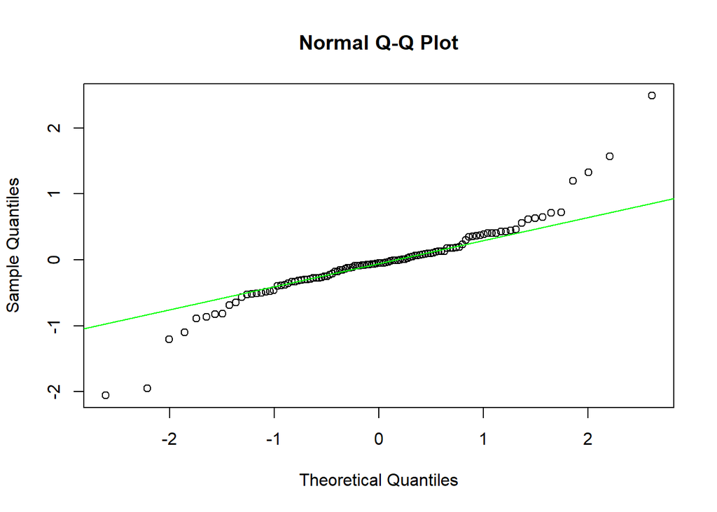

```r
#Eksplorasi
sisaan.da <- model4.da$residuals
par(mfrow=c(1,1))
qqnorm(sisaan.da)
qqline(sisaan.da, col = "green", lwd = 1)
```

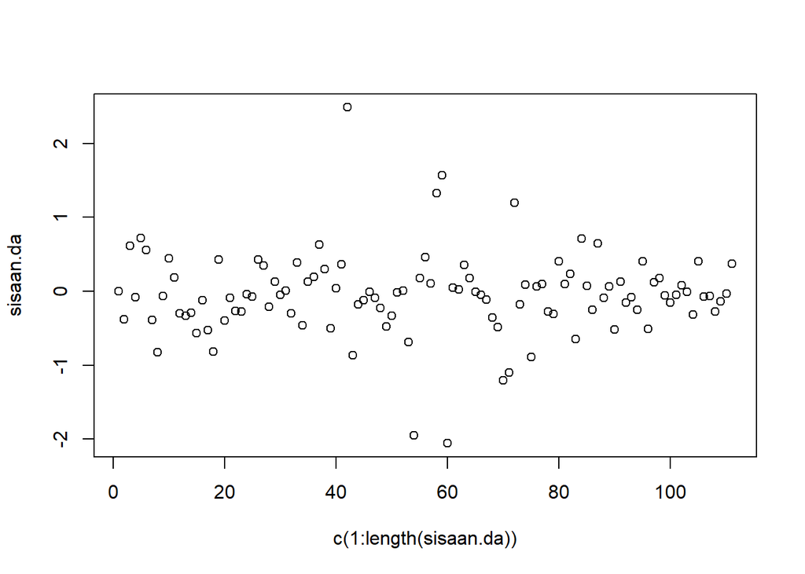

```r
plot(c(1:length(sisaan.da)),sisaan.da)
```

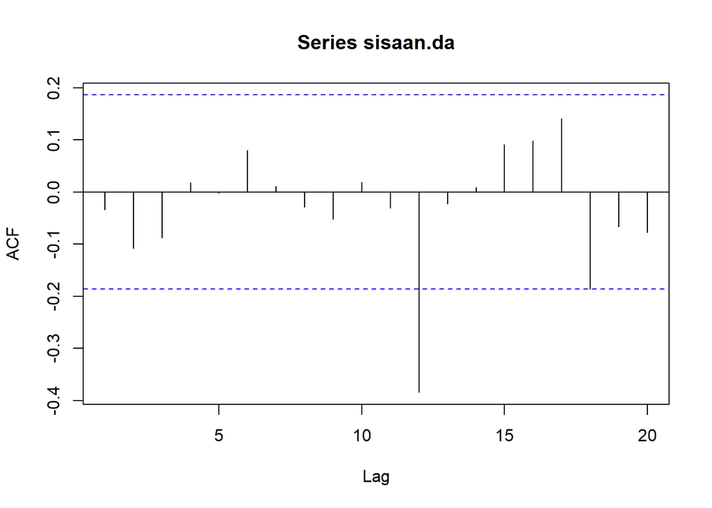

```r
acf(sisaan.da)
```

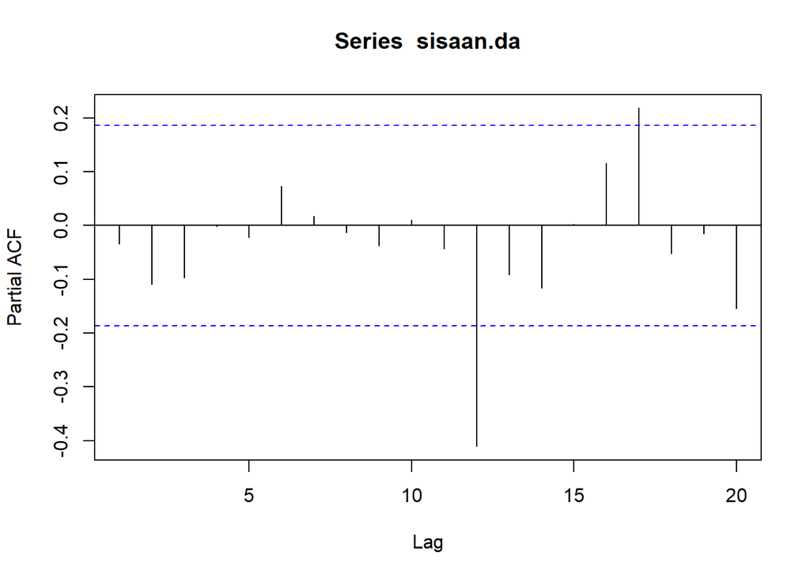

```r
pacf(sisaan.da)
```

```r
par(mfrow = c(1,1))
```

#### Uji Formal

```r
#1) Sisaan Menyebar Normal
ks.test(sisaan.da,"pnorm")  #tak tolak H0 > sisaan menyebar normal
```

```
##
##  Asymptotic one-sample Kolmogorov-Smirnov test
##
## data:  sisaan.da
## D = 0.23191, p-value = 1.305e-05
## alternative hypothesis: two-sided
```

Selain dengan eksplorasi, asumsi tersebut dapat diuji menggunakan uji formal. Pada tahapan ini uji formal yang digunakan untuk normalitas adalah uji Kolmogorov-Smirnov (KS). Hipotesis pada uji KS adalah sebagai berikut.

$H_0$ : Sisaan menyebar normal

$H_1$ : Sisaan tidak menyebar normal

Berdasarkan uji KS tersebut, didapat *p-value* sebesar 0.00001305 yang kurang dari taraf nyata 5% sehingga tolak $H_0$ dan menandakan bahwa sisaan tidak menyebar normal. Hal ini sesuai dengan hasil eksplorasi menggunakan plot kuantil-kuantil normal.

```r
#2) Sisaan saling bebas/tidak ada autokorelasi
Box.test(sisaan.da, type = "Ljung")  #tak tolak H0 > sisaan saling bebas
```

```
##
##  Box-Ljung test
##
## data:  sisaan.da
## X-squared = 0.13454, df = 1, p-value = 0.7138
```

Selanjutnya akan dilakukan uji formal untuk kebebasan sisaan menggunakan uji Ljung-Box. Hipotesis yang digunakan adalah sebagai berikut.

$H_0$ : Sisaan saling bebas

$H_1$ : Sisaan tidak tidak saling bebas

Berdasarkan uji Ljung-Box tersebut, didapat *p-value* sebesar 0.7138 yang lebih besar dari taraf nyata 5% sehingga tak tolak $H_0$ dan menandakan bahwa sisaan saling bebas. Hal ini berbeda dengan eksplorasi.

```r
#3) Sisaan homogen
Box.test((sisaan.da)^2, type = "Ljung")  #tak tolak H0 > sisaan homogen
```

```
##
##  Box-Ljung test
##
## data:  (sisaan.da)^2
## X-squared = 4.8354, df = 1, p-value = 0.02788
```

Hipotesis yang digunakan untuk uji kehomogenan ragam adalah sebagai berikut.

$H_0$ : Ragam sisaan homogen

$H_1$ : Ragam sisaan tidak homogen

```r
#4) Nilai tengah sisaan sama dengan nol
t.test(sisaan.da, mu = 0, conf.level = 0.95)  #tak tolak h0 > nilai tengah sisaan sama dengan 0
```

```
##
##  One Sample t-test
##
## data:  sisaan.da
## t = -0.83493, df = 110, p-value = 0.4056
## alternative hypothesis: true mean is not equal to 0
## 95 percent confidence interval:
##  -0.15095652  0.06146303
## sample estimates:
##   mean of x
## -0.04474674
```

Terakhir, dengan uji-t, akan dicek apakah nilai tengah sisaan sama dengan nol. Hipotesis yang diujikan sebagai berikut.

$H_0$ : nilai tengah sisaan sama dengan 0

$H_1$ : nilai tengah sisaan tidak sama dengan 0

Berdasarkan uji-ttersebut, didapat *p-value* sebesar 0.4056 yang lebih besar dari taraf nyata 5% sehingga tak tolak $H_0$ dan menandakan bahwa nilai tengah sisaan sama dengan nol. Hal ini berbeda dengan eksplorasi.

### Overfitting

Tahapan selanjutnya adalah overfitting dilakukan dengan menaikkan orde AR(p) dan MA(q) dari model ARIMA(0,1,2) untuk melihat apakah terdapat model lain yang lebih baik dari model saat ini. Kandidat model overfitting adalah ARIMA(1,1,2) dan ARIMA(0,1,3).

#### Model ARIMA(1,1,2)

```r
model.overfit1=Arima(train.diff, order=c(1,1,2),method="ML")
summary(model.overfit1) #199.45
```

```
## Series: train.diff
## ARIMA(1,1,2)
##
## Coefficients:
##           ar1      ma1      ma2
##       -0.1097  -0.5386  -0.4613
## s.e.   0.2095   0.1824   0.1802
##
## sigma^2 = 0.3288:  log likelihood = -95.53
## AIC=199.07   AICc=199.45   BIC=209.87
##
## Training set error measures:
##                       ME      RMSE       MAE  MPE MAPE      MASE        ACF1
## Training set -0.04707547 0.5629567 0.3692425 -Inf  Inf 0.7721802 -0.01812619
```

```r
lmtest::coeftest(model.overfit1) #ar1 tidak signifikan
```

```
##
## z test of coefficients:
##
##     Estimate Std. Error z value Pr(>|z|)
## ar1 -0.10966    0.20951 -0.5234  0.60069
## ma1 -0.53864    0.18236 -2.9537  0.00314 **
## ma2 -0.46134    0.18015 -2.5608  0.01044 *
## ---
## Signif. codes:  0 '***' 0.001 '**' 0.01 '*' 0.05 '.' 0.1 ' ' 1
```

#### Model ARIMA(0,1,3)

```r
model.overfit2=Arima(train.diff, order=c(0,1,3),method="ML")
summary(model.overfit2) #199.25
```

```
## Series: train.diff
## ARIMA(0,1,3)
##
## Coefficients:
##           ma1      ma2     ma3
##       -0.6664  -0.4041  0.0705
## s.e.   0.1076   0.0974  0.1012
##
## sigma^2 = 0.3279:  log likelihood = -95.43
## AIC=198.87   AICc=199.25   BIC=209.67
##
## Training set error measures:
##                       ME     RMSE      MAE  MPE MAPE      MASE         ACF1
## Training set -0.04946505 0.562224 0.369061 -Inf  Inf 0.7718005 -0.004842621
```

```r
lmtest::coeftest(model.overfit2) #ma3 tidak signifikan
```

```
##
## z test of coefficients:
##
##      Estimate Std. Error z value  Pr(>|z|)
## ma1 -0.666356   0.107604 -6.1926 5.916e-10 ***
## ma2 -0.404150   0.097379 -4.1503 3.321e-05 ***
## ma3  0.070507   0.101197  0.6967     0.486
## ---
## Signif. codes:  0 '***' 0.001 '**' 0.01 '*' 0.05 '.' 0.1 ' ' 1
```

Model yang dipilih adalah model awal yaitu ARIMA (0,1,2)

### Peramalan

Peramalan dilakukan menggunakan fungsi `forecast()` . Contoh peramalan berikut ini dilakukan untuk 30 hari ke depan.

```r
#---FORECAST---#
ramalan.da <- forecast::forecast(model4.da, h = 30)
ramalan.da
```

```
##     Point Forecast      Lo 80     Hi 80      Lo 95    Hi 95
## 113    0.131694550 -0.6041806 0.8675697 -0.9937294 1.257119
## 114   -0.005768456 -0.7936654 0.7821285 -1.2107529 1.199216
## 115   -0.005768456 -0.7936654 0.7821285 -1.2107529 1.199216
## 116   -0.005768456 -0.7936654 0.7821285 -1.2107529 1.199216
## 117   -0.005768456 -0.7936654 0.7821285 -1.2107529 1.199216
## 118   -0.005768456 -0.7936654 0.7821285 -1.2107529 1.199216
## 119   -0.005768456 -0.7936654 0.7821285 -1.2107529 1.199216
## 120   -0.005768456 -0.7936654 0.7821285 -1.2107529 1.199216
## 121   -0.005768456 -0.7936654 0.7821285 -1.2107529 1.199216
## 122   -0.005768456 -0.7936654 0.7821285 -1.2107529 1.199216
## 123   -0.005768456 -0.7936654 0.7821285 -1.2107529 1.199216
## 124   -0.005768456 -0.7936654 0.7821285 -1.2107529 1.199216
## 125   -0.005768456 -0.7936654 0.7821285 -1.2107529 1.199216
## 126   -0.005768456 -0.7936654 0.7821285 -1.2107529 1.199216
```

[output cut: 16 more lines]

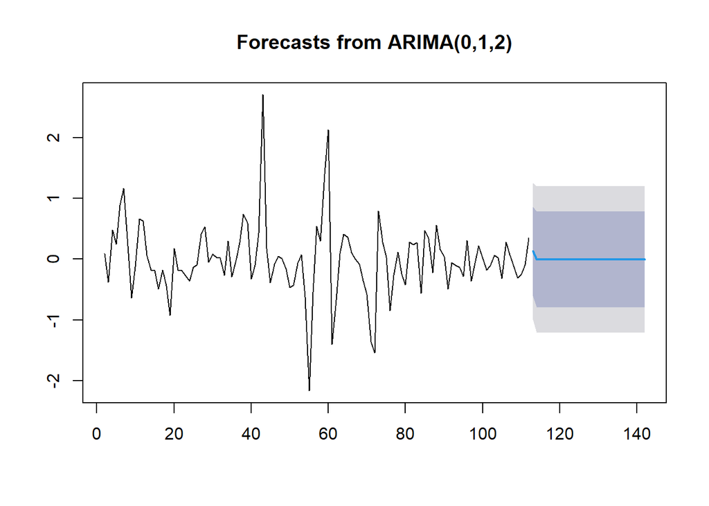

```r
data.ramalan.da <- ramalan.da$mean
plot(ramalan.da)
```

Berdasarkan hasil plot ramalan di atas, dapat dilihat bahwa ramalan ARIMA(0,1,2) cenderung stabil hingga akhir periode. Selanjutnya, dapat dicari nilai akurasi antara hasil ramalan dengan data uji sebagai berikut.

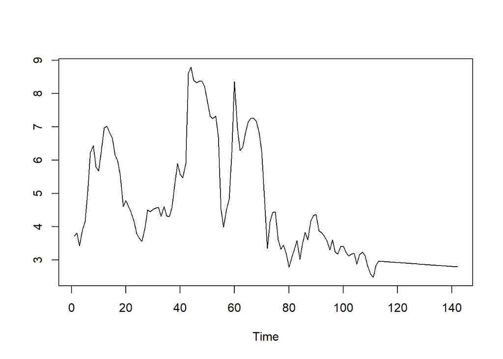

```r
pt_1 <- train.ts[112] #nilai akhir data latih
hasil.forc.Diff <- data.ramalan.da
hasil <- diffinv(hasil.forc.Diff, differences = 1) + pt_1
#has.1 sama hasilnya dengan: cumsum(c(pt_1,hasil.forc.Diff))
ts.plot(train.ts,hasil)
```

```r
perbandingan.da<-matrix(data=c(head(test.ts, n=30), hasil[-1]),
                     nrow = 30, ncol = 2)
colnames(perbandingan.da)<-c("Aktual","Hasil Forecast")
perbandingan.da
```

```
##       Aktual Hasil Forecast
##  [1,]   3.32       2.961695
##  [2,]   3.28       2.955926
##  [3,]   3.32       2.950158
##  [4,]   3.49       2.944389
##  [5,]   3.39       2.938621
##  [6,]   3.13       2.932852
##  [7,]   3.00       2.927084
##  [8,]   2.72       2.921315
##  [9,]   2.68       2.915547
## [10,]   2.98       2.909778
## [11,]   2.96       2.904010
## [12,]   2.67       2.898242
## [13,]   2.19       2.892473
## [14,]   1.96       2.886705
```

[output cut: 16 more lines]

```r
accuracy(ts(hasil[-1]), head(test.ts, n=30))
```

```
##                  ME     RMSE       MAE       MPE    MAPE      ACF1 Theil's U
## Test set -0.7053853 1.017976 0.8684178 -48.86672 53.7826 0.9223229  6.695751
```

Didapati bahwa nilai MAPE mencapai 53.78%, yang mengindikasikan bahwa model prediksi rata-rata mengalami deviasi sekitar 54% dari nilai sebenarnya. Saat dilakukan pengecekan stasioneritas, ditemukan bahwa data tidak menunjukkan stasioneritas baik dalam rataan maupun dalam ragam. Namun, dalam analisis ini, hanya masalah ketidakstasioneran dalam rataan yang telah diatasi. Sayangnya, ketidakstasioneran dalam ragam masih menjadi permasalahan yang belum terpecahkan. Hal ini dapat berpotensi menjadi salah satu penyebab mengapa nilai MAPE dari model masih relatif tinggi.